# Statistics: The Science of Decisions

### Background Information

In a Stroop task, participants are presented with a list of words, with each word displayed in a color of ink. The participant’s task is to say out loud the color of the ink in which the word is printed. The task has two conditions: a congruent words condition, and an incongruent words condition. In the congruent words condition, the words being displayed are color words whose names match the colors in which they are printed: for example RED, BLUE. In the incongruent words condition, the words displayed are color words whose names do not match the colors in which they are printed: for example PURPLE, ORANGE. In each case, we measure the time it takes to name the ink colors in equally-sized lists. Each participant will go through and record a time from each condition.

#### 1. What is our independent variable? What is our dependent variable?

**Independent variable:** Condition of the task(congruent words, or incongruent words)

**Dependent variable:** the time it takes to name the ink colors in equally-sized lists

#### 2. What is an appropriate set of hypotheses for this task? What kind of statistical test do you expect to perform? Justify your choices.

Where μ1 is the average population time taken in congruent words condition and μ2 is the average population time taken in incongruent words condition.

**Null Hypothesis:** μ1 = μ2 or μ1 - μ2 = 0

The average response time of the population doesn't change in the two conditions.

**Alternative Hypothesis:** μ1 - μ2 < 0

The average response time of the population is much less if congruent words condition.

We use **one-tailed dependent t-test in negative direction**.

This experient has dependent samples with two conditions, and we do not know the population standard deviation. We want to compare the time consumed by congruent words is significantly less, so its in the negative direction.

```python
import pandas as pd
```

```python
path = r'~/Downloads/stroopdata.csv'
# Change the path to the location where the chopstick-effectiveness.csv file is located on your computer.
# If you get an error when running this block of code, be sure the chopstick-effectiveness.csv is located at the path on your computer.

dataFrame = pd.read_csv(path)
difference = dataFrame['Congruent']-dataFrame['Incongruent']
difference.mean()
```

```
-7.964791666666667
```

```python
difference.std()
```

```
4.864826910359056
```

#### 3. Report some descriptive statistics regarding this dataset. Include at least one measure of central tendency and at least one measure of variability.

The mean of the differences is -7.96

The standard deviation of the differences is 4.86

The standard error of the mean is 0.993

#### 4. Provide one or two visualizations that show the distribution of the sample data. Write one or two sentences noting what you observe about the plot or plots.

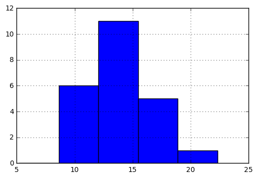

```python
%pylab inline

import matplotlib.pyplot as plt
dataFrame['Congruent'].hist(bins=[5.21,8.63,12.05,15.47,18.9,22.31])
```

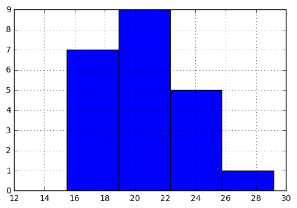

```python
dataFrame['Incongruent'].hist(bins=[12.05,15.47,18.9,22.31,25.73,29.17])
```

#### 5. Now, perform the statistical test and report your results. What is your confidence level and your critical statistic value? Do you reject the null hypothesis or fail to reject it? Come to a conclusion in terms of the experiment task. Did the results match up with your expectations?

The t-statistics = -8.02

The t critical value at alpha = 0.05 is -1.714, 95% confidence level

There for we reject the null hypothesis. Participants uses significantly less time reading through a list of congruent words than list of incongruent words of same length.

Yes, they match up with my expectations.

#### 6. Optional: What do you think is responsible for the effects observed? Can you think of an alternative or similar task that would result in a similar effect? Some research about the problem will be helpful for thinking about these two questions!

Lag of speed between word processing and color processing of our brains.

**Similar task:** Names of color printed in black ink that have to be read.